# Ex5B_results

Zoey Werbin

3/3/2019

# Exercise 5B: Bayesian Regression using Gibbs Sampling

```
## Linked to JAGS 4.3.0
```

```
## Loaded modules: basemod,bugs
```

In this exercise we evaluate an MCMC’s ability to recover the “true” parameters of the model, for both a univariate and multivariate model. We first simulate data from known parameters.

```r
### Part 1: simulate data from a known model
n <- 100            ## define the sample size
b0 <- 10                ## define the intercept
b1 <- 2                 ## define the slope
beta <- matrix(c(b0,b1),2,1)        ## put “true” regression parameters in a matrix
sigma <- 4              ## define the standard deviation
```

Now let’s create our design matrix and multiply it by our covariate matrix. We’ll save it as a list.

```r
x1 <- runif(n,0,20)
x <- cbind(rep(1,n),x1)
y <- rnorm(n,x%*%beta,sigma)
data <- list(x = x1, y = y, n = n)
```

Here we specify the model, priors, and initial conditions.

```r
univariate_regression <- "
model{

  beta ~ dmnorm(b0,Vb)      ## multivariate Normal prior on vector of regression params
  prec ~ dgamma(s1,s2)    ## prior precision

  for(i in 1:n){
      mu[i] <- beta[1] + beta[2]*x[i]       ## process model
      y[i]  ~ dnorm(mu[i],prec)             ## data model
  }
}
"

## specify priors
data$b0 <- as.vector(c(0,0))      ## regression beta means
data$Vb <- solve(diag(10000,2))   ## regression beta precisions
data$s1 <- 0.1                    ## error prior n/2
data$s2 <- 0.1                    ## error prior SS/2

## initial conditions
nchain = 3
inits <- list()
for(i in 1:nchain){
 inits[[i]] <- list(beta = rnorm(2,0,5), prec = runif(1,1/100,1/20))
}
```

Compile and initialize the model:

```r
j.model   <- jags.model(file = textConnection(univariate_regression),
                             data = data,
                             inits = inits,
                             n.chains = nchain)
```

Use the coda.samples function to sample from the posterior:

```r
var.out   <- coda.samples (model = j.model,
                            variable.names = c("beta","prec"),
                                n.iter = 2000)
```

## Task 1: Evaluate model for convergence.

- Evaluate the MCMC chain for convergence. Include relevant diagnostics and plots. Determine and remove burnin e.g. `var.burn <- window(var.out,start=burnin)`
- Report parameter summary table and plot marginal distributions
- Describe and explain the parameter covariances that you observe in the pairs plot and parameter correlation matrix.
- Compare the summary statistics for the Bayesian regression model to those from the classical regression: summary(lm( y ~ x1 )). This should include a comparison of the means and uncertainties of **all 3 model parameters**
- Compare the fit parameters to the “true” parameters we used to generate the pseudo-data. How well does the statistical analysis recover the true model?

```r
# Assess model convergence:
gelman.diag(var.out)
```

```
## Potential scale reduction factors:
##
##         Point est. Upper C.I.
## beta[1]          1          1
## beta[2]          1          1
## prec             1          1
##
## Multivariate psrf
##
## 1
```

Values of 1 for all parameters - model has converged.

Next, let’s assess the burn-in.

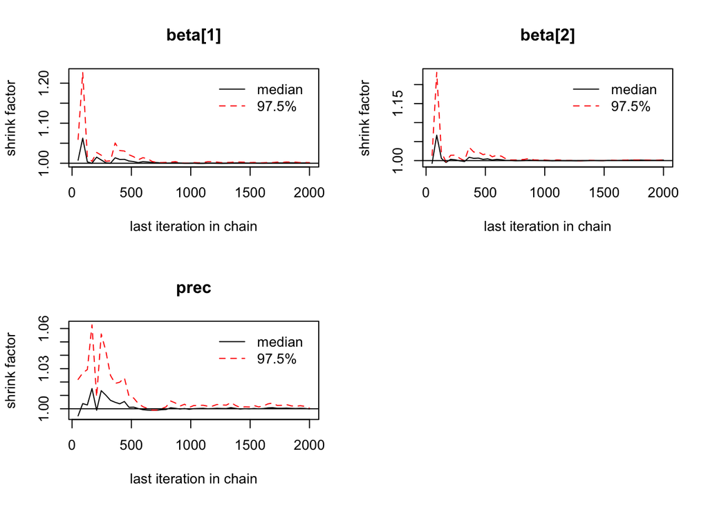

```r
GBR <- gelman.plot(var.out)
```

Removing about 800 iterations should be good. Let’s also check the effective sample sizes.

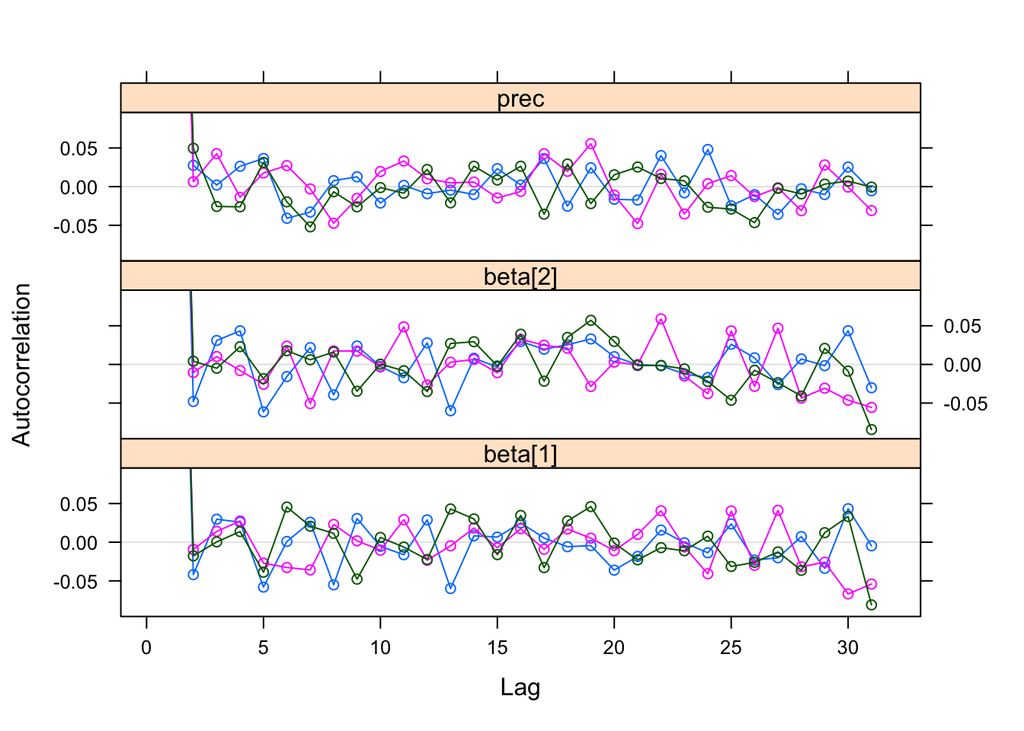

```r
burnin = 800                                ## determine convergence
var.out <- window(var.out,start=burnin)  ## remove burn-in

acfplot(var.out) # autocorrelation plot
```

```r
effectiveSize(var.out) # check effective sample sizes
```

```
##  beta[1]  beta[2]     prec
## 3706.998 3676.120 3488.592
```

These values are higher than our 2000 samples, so let’s get some extra samples.

```r
var.out2 <- coda.samples(j.model,variable.names = c("beta","prec"),5000)
#var.out2 <- var.out
```

Now we can calculate summary stats.

```r
summary(var.out2)
```

```
##
## Iterations = 2001:7000
## Thinning interval = 1
## Number of chains = 3
## Sample size per chain = 5000
##
## 1. Empirical mean and standard deviation for each variable,
##    plus standard error of the mean:
##
##             Mean       SD  Naive SE Time-series SE
## beta[1] 10.89205 0.968697 7.909e-03      7.982e-03
## beta[2]  1.87235 0.081774 6.677e-04      6.677e-04
## prec     0.05389 0.007816 6.381e-05      6.499e-05
##
## 2. Quantiles for each variable:
##
##            2.5%     25%      50%      75%    97.5%
## beta[1] 9.01663 10.2425 10.88746 11.53695 12.81541
## beta[2] 1.71083  1.8184  1.87221  1.92714  2.03156
## prec    0.03966  0.0485  0.05349  0.05895  0.07036
```

Let’s also check the trace plots.

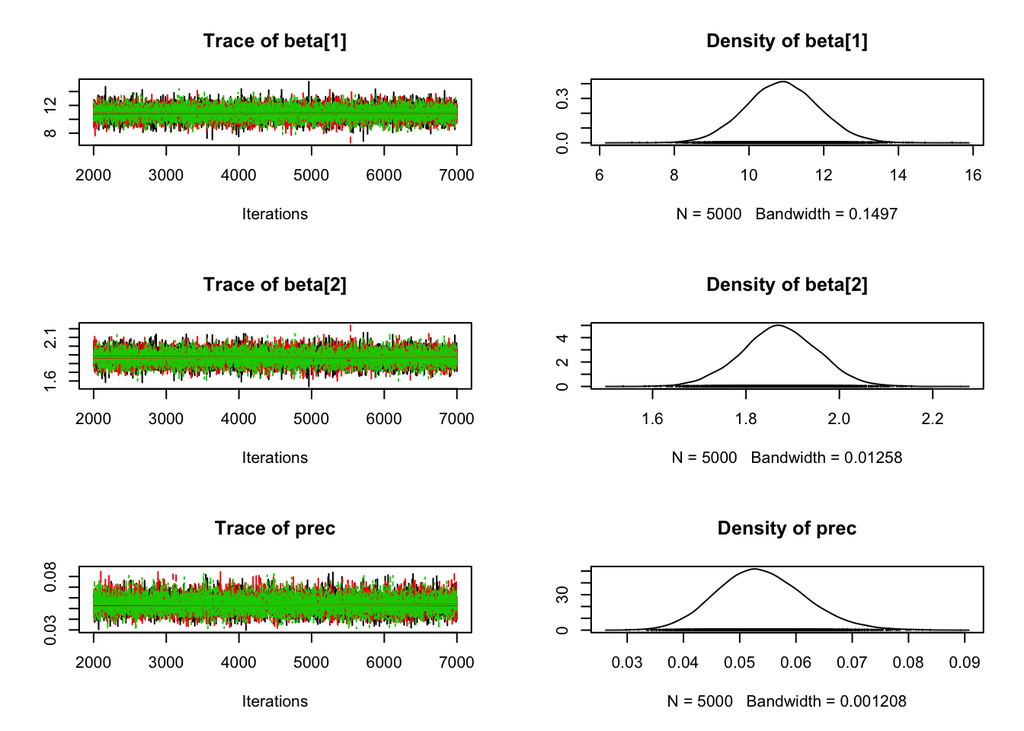

```r
plot(var.out2)
```

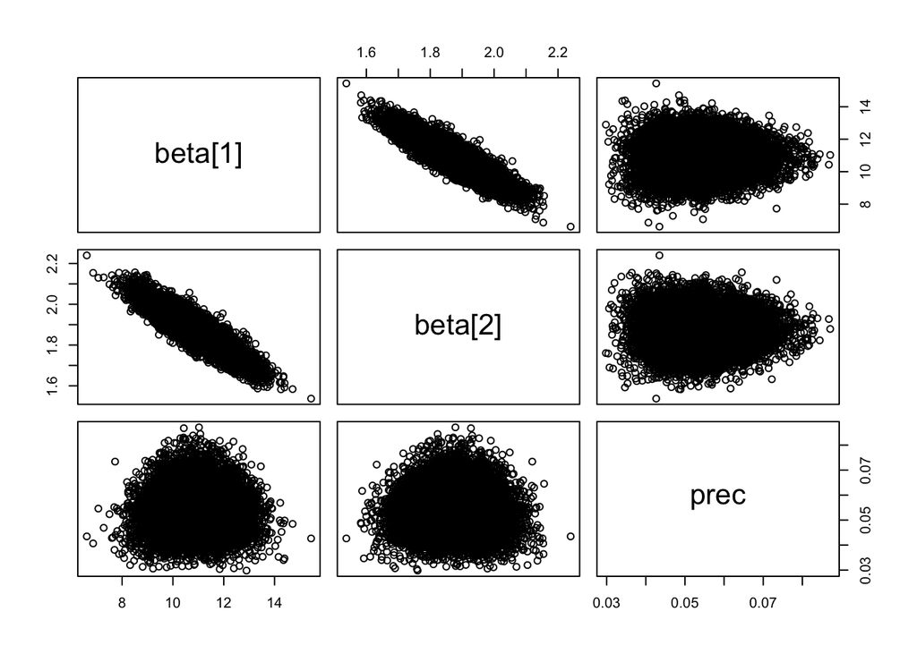

```r
## convert to matrix
var.mat      <- as.matrix(var.out2)

## Pairwise scatter plots & correlation
pairs(var.mat)  ## pairs plot to evaluate parameter correlation
```

```r
cor(var.mat)    ## correlation matrix among model parameters
```

```
##              beta[1]      beta[2]         prec
## beta[1]  1.000000000 -0.892769256  0.003801418
## beta[2] -0.892769256  1.000000000 -0.005550575
## prec     0.003801418 -0.005550575  1.000000000
```

Looks like our slope and intercept are closely correlated, which makes sense because they are both descriptors of the same line. Neither are correlated with the precision, which is good; the precision should be random, otherwise assumptions of non-heteroskedasticity may be violated.

Now let’s compare these results to those of a classical regression:

```r
summary(lm( y ~ x1 ))
```

```
##
## Call:
## lm(formula = y ~ x1)
##
## Residuals:
##      Min       1Q   Median       3Q      Max
## -14.1593  -2.5977  -0.1922   3.3268   8.7607
##
## Coefficients:
##             Estimate Std. Error t value Pr(>|t|)
## (Intercept) 10.88944    0.96111   11.33   <2e-16 ***
## x1           1.87217    0.08091   23.14   <2e-16 ***
## ---
## Signif. codes:  0 '***' 0.001 '**' 0.01 '*' 0.05 '.' 0.1 ' ' 1
##
## Residual standard error: 4.313 on 98 degrees of freedom
## Multiple R-squared:  0.8453, Adjusted R-squared:  0.8437
## F-statistic: 535.4 on 1 and 98 DF,  p-value: < 2.2e-16
```

# Task 2

Extend your univariate regression model to a multivariate regression.

- Show the JAGS and R code used.
- Include relevant convergence diagnostics and plots.
- Report parameter summary table.
- Plot marginal and pairwise joint distributions. Indicate ‘true’ parameters on the plots
- Compare the fit parameters to the “true” parameters we used to generate the pseudo-data. How well does the statistical analysis recover the true model?

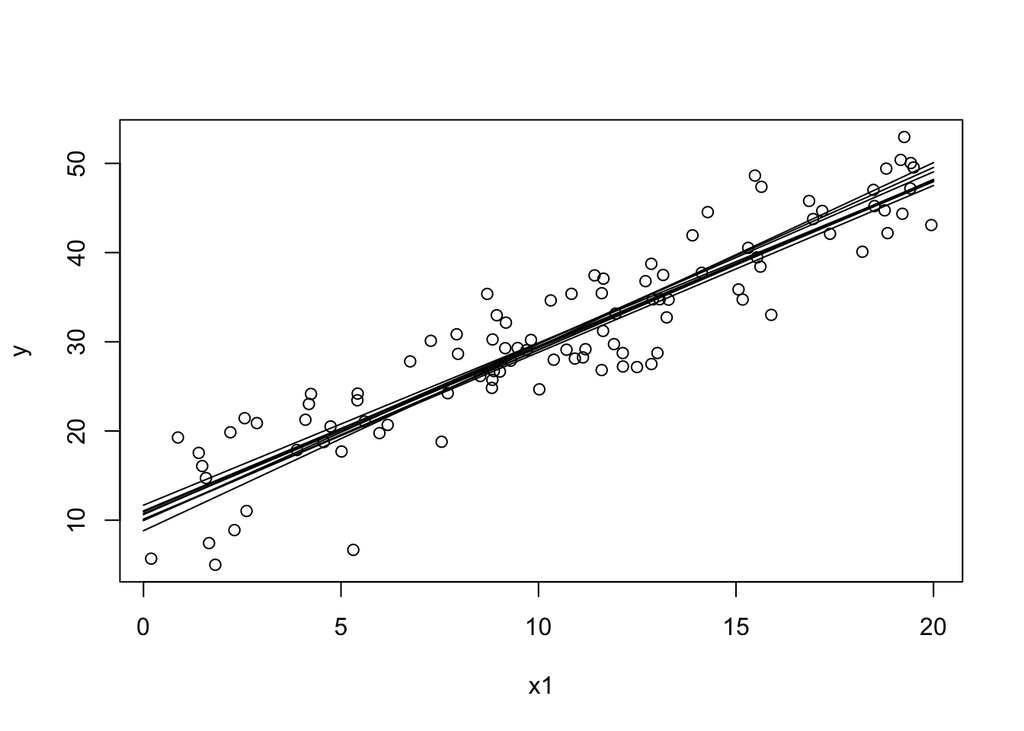

```r
xpred <- 0:20
plot(x1,y)
for(i in 1:10){
  lines(xpred, var.mat[i,"beta[1]"] + var.mat[i,"beta[2]"]*xpred)
}
```

```r
## credible and prediction intervals
nsamp <- 5000
samp <- sample.int(nrow(var.mat),nsamp)
xpred <- 0:20                   ## sequence of x values we're going to
npred <- length(xpred)              ##      make predictions for
ypred <- matrix(0.0,nrow=nsamp,ncol=npred)  ## storage for predictive interval
ycred <- matrix(0.0,nrow=nsamp,ncol=npred)  ## storage for credible interval
```

Next we’ll set up a loop where we’ll calculate the expected value of y at each x for each pair of regression parameters and then add additional random error from the data model. When looping through the posterior MCMC we’ll want to account for any burn-in period and thinning.

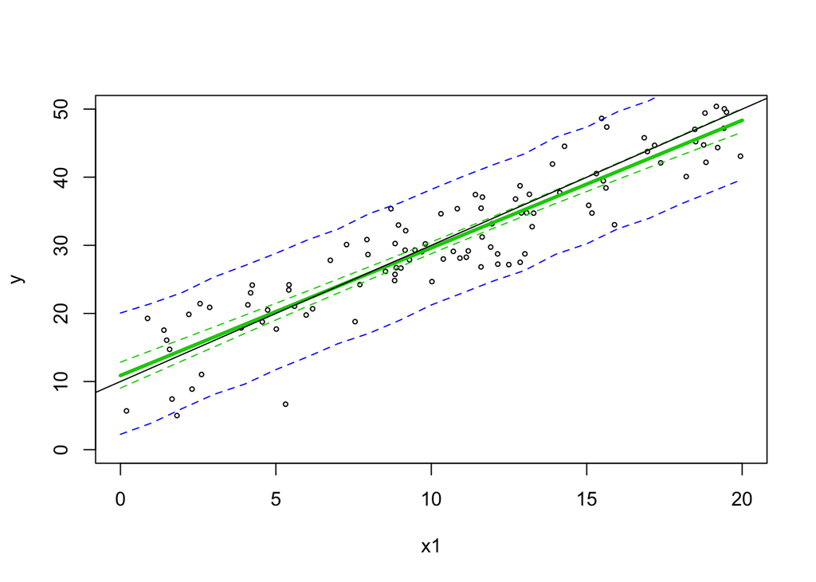

```r
for(g in seq_len(nsamp)){
  theta = var.mat[samp[g],]
  ycred[g,] <- theta["beta[1]"] + theta["beta[2]"]*xpred
  ypred[g,] <- rnorm(npred,ycred[g,],1/sqrt(theta["prec"]))
}

ci <- apply(ycred,2,quantile,c(0.025,0.5,0.975))  ## credible interval and median
pi <- apply(ypred,2,quantile,c(0.025,0.975))        ## prediction interval

plot(x1,y,cex=0.5,xlim=c(0,20),ylim=c(0,50))
lines(xpred,ci[1,],col=3,lty=2) ## lower CI
lines(xpred,ci[2,],col=3,lwd=3) ## median
lines(xpred,ci[3,],col=3,lty=2) ## upper CI
lines(xpred,pi[1,],col=4,lty=2) ## lower PI
lines(xpred,pi[2,],col=4,lty=2) ## upper PI
abline(b0,b1)               ## true model
```

Here we simulate data using known parameters.

```r
### Part 1: simulate data from a known model
n <- 250            ## define the sample size
b0 <- 10                ## define the intercept
b1 <- 2                 ## define slope1
b2 <- -4        ## define slope2
b3 <- 0.5       ## define interaction
beta <- matrix(c(b0,b1,b2,b3),4,1)      ## put “true” regression parameters in a matrix
sigma <- 4              ## define the standard deviation
x1 <- runif(n,0,20)
x2 <- runif(n,0,15)
x <- cbind(rep(1,n),x1,x2,x1*x2)
y <- rnorm(n,x%*%beta,sigma)
```

Pass data to the model, and run the model.

```r
#mod <- model.matrix(~ x1 * x2)
data <- list(x = x, y = y, n = n)

multivariate_regression <- "
model{

  beta ~ dmnorm(b0,Vb)      ## multivariate Normal prior on vector of regression params
  prec ~ dgamma(s1,s2)    ## prior precision

  for(i in 1:n){
      mu[i] <- beta[1] + beta[2]*x[i,2] + beta[3]*x[i,3] + beta[4]*x[i,4]   ## process model
      y[i]  ~ dnorm(mu[i],prec)             ## data model
  }
}
"

## specify priors
data$b0 <- as.vector(c(0,0,0,0))      ## regression beta means
data$Vb <- solve(diag(10000,4))   ## regression beta precisions
data$s1 <- 0.1                    ## error prior n/2
data$s2 <- 0.1                    ## error prior SS/2

## initial conditions
nchain = 3
inits <- list()
for(i in 1:nchain){
 inits[[i]] <- list(beta = rnorm(4,0,5), prec = runif(1,1/100,1/20))
}

j.model   <- jags.model(file = textConnection(multivariate_regression),
                             data = data,
                             inits = inits,
                             n.chains = nchain)
var.out   <- coda.samples (model = j.model,
                            variable.names = c("beta","prec"),
                                n.iter = 5000)
```

```r
# Assess model convergence:
gelman.diag(var.out)
```

```
## Potential scale reduction factors:
##
##         Point est. Upper C.I.
## beta[1]          1          1
## beta[2]          1          1
## beta[3]          1          1
## beta[4]          1          1
## prec             1          1
##
## Multivariate psrf
##
## 1
```

Values of 1 for all parameters - model has converged.

Next, let’s assess the burn-in.

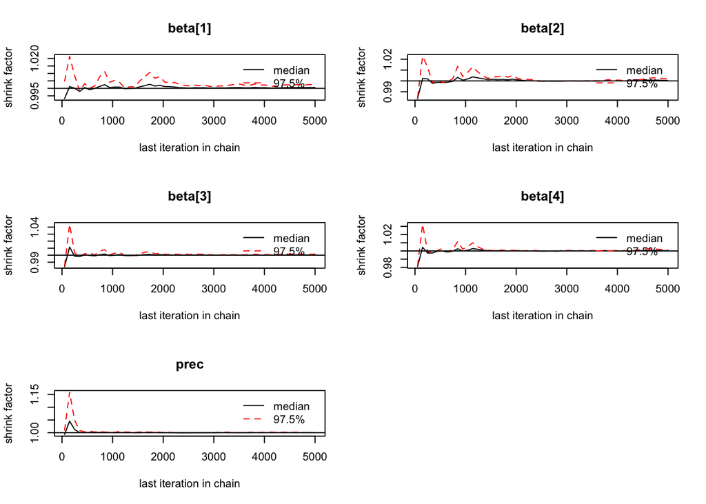

```r
GBR <- gelman.plot(var.out)
```

Removing about 800 iterations should be good, though 500 may have been enough. Let’s also check the effective sample sizes.

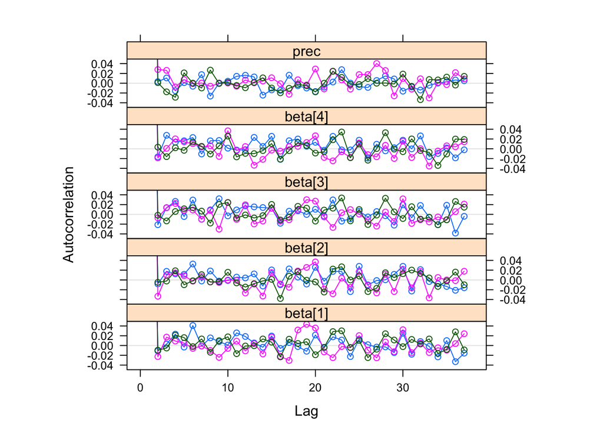

```r
burnin = 800                                ## determine convergence
var.out <- window(var.out,start=burnin)  ## remove burn-in

acfplot(var.out) # autocorrelation plot
```

```r
effectiveSize(var.out) # check effective sample sizes
```

```
##  beta[1]  beta[2]  beta[3]  beta[4]     prec
## 12796.80 12891.56 12603.00 12511.26 12175.36
```

```r
var.out2 <- coda.samples(j.model,variable.names = c("beta","prec"),4000)
```

Now let’s check the trace plots.

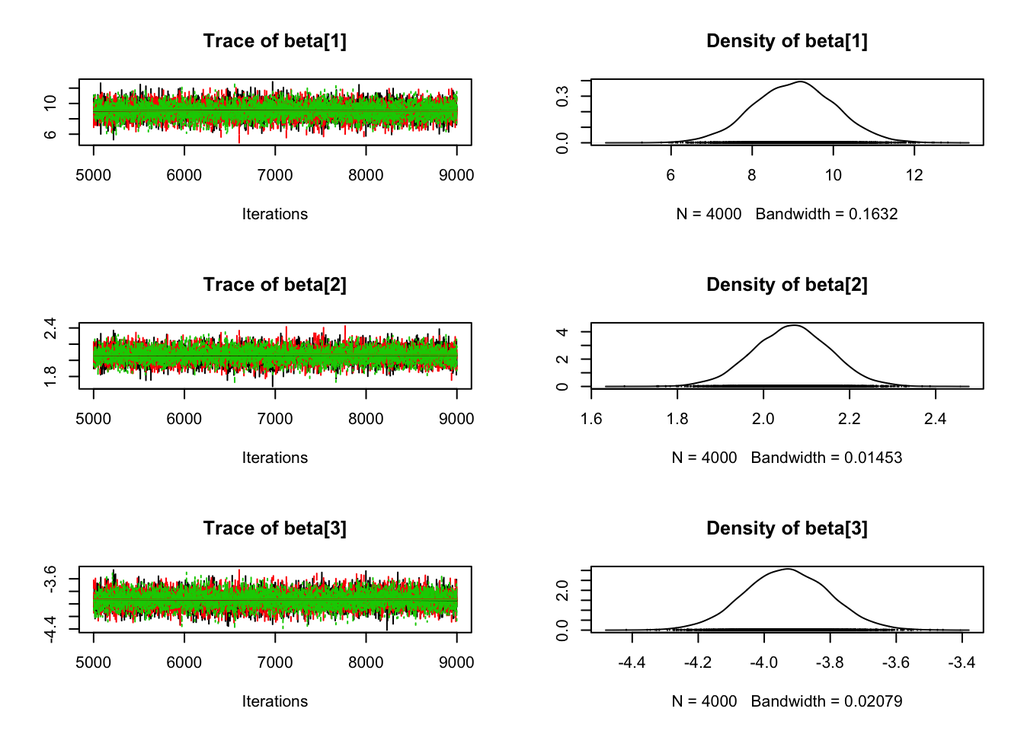

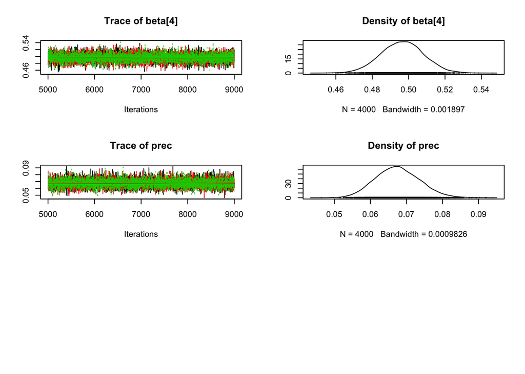

```r
plot(var.out2)
```

These chains look well-mixed. Now let’s assess parameter correlation.

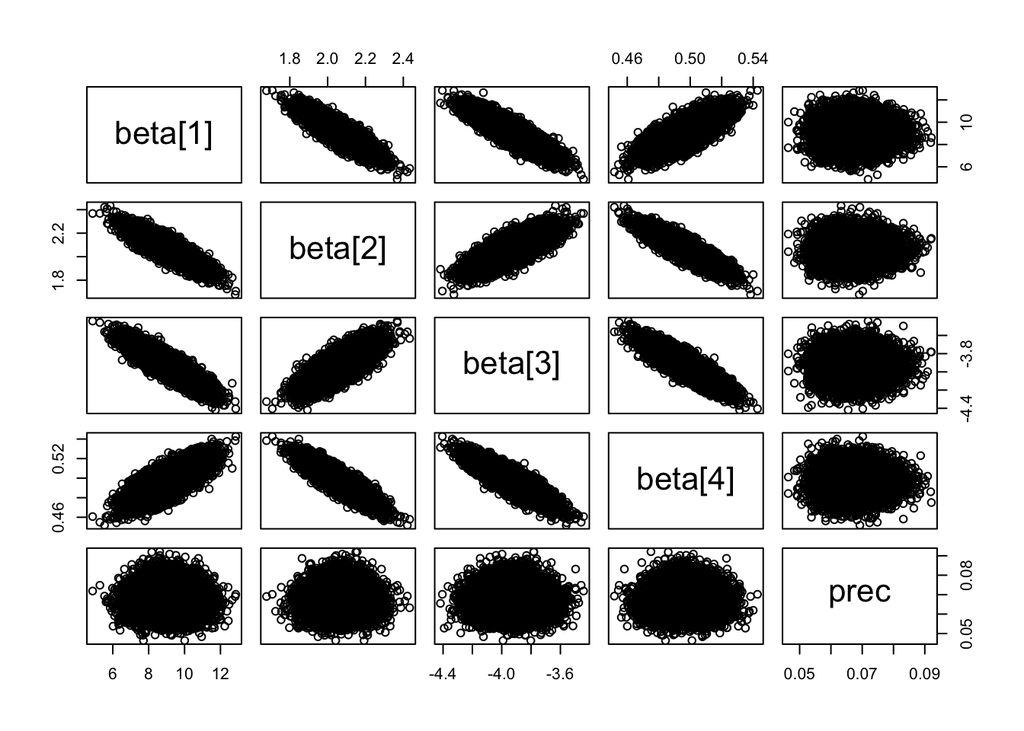

```r
## convert to matrix
var.mat      <- as.matrix(var.out2)

## Pairwise scatter plots & correlation
pairs(var.mat)  ## pairs plot to evaluate parameter correlation
```

```r
cor(var.mat)    ## correlation matrix among model parameters
```

```
##             beta[1]      beta[2]      beta[3]      beta[4]         prec
## beta[1]  1.00000000 -0.868072054 -0.872598806  0.755873097 -0.002856380
## beta[2] -0.86807205  1.000000000  0.769110133 -0.877775543 -0.003316926
## beta[3] -0.87259881  0.769110133  1.000000000 -0.873423857  0.001010981
## beta[4]  0.75587310 -0.877775543 -0.873423857  1.000000000  0.004294166
## prec    -0.00285638 -0.003316926  0.001010981  0.004294166  1.000000000
```

Here we see that once again, our precision is uncorrelated with our other parameters. There are high (>.73) correlations between each slope or interaction parameter. This makes sense because they are sampled simultaneously and describe the same line. The precision values hover evenly around the ‘true’ values.

Finally, we can calculate summary stats.

```r
summary(var.out2)
```

```
##
## Iterations = 5001:9000
## Thinning interval = 1
## Number of chains = 3
## Sample size per chain = 4000
##
## 1. Empirical mean and standard deviation for each variable,
##    plus standard error of the mean:
##
##             Mean       SD  Naive SE Time-series SE
## beta[1]  9.04225 1.007649 9.199e-03      9.209e-03
## beta[2]  2.06574 0.089694 8.188e-04      8.252e-04
## beta[3] -3.93120 0.128364 1.172e-03      1.186e-03
## beta[4]  0.49648 0.011709 1.069e-04      1.059e-04
## prec     0.06756 0.006066 5.538e-05      5.633e-05
##
## 2. Quantiles for each variable:
##
##             2.5%      25%      50%      75%    97.5%
## beta[1]  7.05126  8.35368  9.05694  9.72303 11.01945
## beta[2]  1.88807  2.00493  2.06646  2.12616  2.24063
## beta[3] -4.18286 -4.01853 -3.93161 -3.84408 -3.67608
## beta[4]  0.47343  0.48852  0.49655  0.50433  0.51918
## prec     0.05627  0.06334  0.06738  0.07158  0.07991
```